# Google Data Analytics Capstone Case Study 1

2022-07-29

## Ask

##### Guiding questions

- What is the problem you are trying to solve?
  - The goal is to build a marketing strategies to covert casual riders to annual members.
- How can your insights drive business decisions?
  - The insights will help the marketing team to increase the annual members.

## Prepare

##### Guiding questions

- Where is your data located?
  - The data is located in the Google database; link is provided with the case study description
- How is the data organized?
  - The data is separated by month, each on its own csv (between July 2021 and June 2022).
- Are there issues with bias or credibility in this data? Does your data ROCCC?
  - There are not any issues with bias, since the population of the dataset is its own clients as bike riders. It’s ROCC because it’s reliable, original, comprehensive, current, and cited.
- How are you addressing licnesing, privacy, security, and accessibility?
  - The company has their own license over the dataset. The dataset does not have personal information about the riders.
- How did you verify the data’s integrity?
  - All the files have consistent names, columns and each column has the correct data type.
- How does it help you answer your question?
  - It contains some key insights about the routine activities of riders.
- Are there any problems with the data?
  - It would be more helpful if there’s more information about the riders.

## Process

##### Guiding questions

- What tools are you choosing and why?
  - Here, I’m using R to merge the data of 12 months into 1 large data-frame because it’s easier to merge a large dataset.
- Have you ensured your data’s integrity?
  - Yes, the data is consistent throughout the columns.
- What steps have you taken to ensure that your data is clean?
  - First, I removed duplicates. Then, I re-format the date and time of the columns.
- How can you verify that your data is clean and ready to analyze?
  - It can be verified by this document.
- Have you documented your cleaning process so you can review and share those results?
  - Yes, it’s all documented in this R notebook.

### Code

###### Dependences

```r
library(tidyverse)
```

##### Concatenating

Concatenating csv files

```r
csv_files <- list.files(path = "data", recursive = TRUE, full.names=TRUE)

df <- do.call(rbind, lapply(csv_files, read.csv))

head(df, 5)
```

|  | ride_id | rideable_type | started_at | ended_at | start_station_name | start_station_id | end_station_name | end_station_id | start_lat | start_lng | end_lat | end_lng | member_casual |
| --- | --- | --- | --- | --- | --- | --- | --- | --- | --- | --- | --- | --- | --- |
| 1 | 0A1B623926EF4E16 | docked_bike | 2021-07-02 14:44:36 | 2021-07-02 15:19:58 | Michigan Ave & Washington St | 13001 | Halsted St & North Branch St | KA1504000117 | 41.88398 | -87.62468 | 41.89937 | -87.64848 | casual |
| 2 | B2D5583A5A5E76EE | classic_bike | 2021-07-07 16:57:42 | 2021-07-07 17:16:09 | California Ave & Cortez St | 17660 | Wood St & Hubbard St | 13432 | 41.90036 | -87.69670 | 41.88990 | -87.67147 | casual |
| 3 | 6F264597DDBF427A | classic_bike | 2021-07-25 11:30:55 | 2021-07-25 11:48:45 | Wabash Ave & 16th St | SL-012 | Rush St & Hubbard St | KA1503000044 | 41.86038 | -87.62581 | 41.89017 | -87.62619 | member |
| 4 | 379B58EAB20E8AA5 | classic_bike | 2021-07-08 22:08:30 | 2021-07-08 22:23:32 | California Ave & Cortez St | 17660 | Carpenter St & Huron St | 13196 | 41.90036 | -87.69670 | 41.89456 | -87.65345 | member |
| 5 | 6615C1E4EB08E8FB | electric_bike | 2021-07-28 16:08:06 | 2021-07-28 16:27:09 | California Ave & Cortez St | 17660 | Elizabeth (May) St & Fulton St | 13197 | 41.90035 | -87.69668 | 41.88659 | -87.65839 | casual |

#### Data Cleaning

##### Removing duplicates

```r
df_no_dups <- df[!duplicated(df), ]
print(paste("Removed", nrow(df) - nrow(df_no_dups), "duplicated rows"))
```

```
[1] "Removed 0 duplicated rows"
```

##### Parse datetime columns

```r
df_no_dups$started_at <- as.POSIXct(df_no_dups$started_at, "%Y-%m-%d %H:%M:%S")
df_no_dups$ended_at <- as.POSIXct(df_no_dups$ended_at, "%Y-%m-%d %H:%M:%S")
```

##### ride_time_minute

The total ride time in minutes

```r
df_no_dups <- df_no_dups %>%
  mutate(ride_time_minutes = as.numeric(df_no_dups$ended_at - df_no_dups$started_at)/ 60)

summary(df_no_dups$ride_time_minutes)
```

```
    Min.  1st Qu.   Median     Mean  3rd Qu.     Max.
 -137.42     6.28    11.17    20.28    20.20 49107.15
```

##### year_month

Separate the year and month might be helful

```r
df_no_dups <- df_no_dups %>%
    mutate(year_month = paste(strftime(df_no_dups$started_at, "%Y"),
                              "-",
                              strftime(df_no_dups$started_at, "%m"),
                              "(", strftime(df_no_dups$started_at, "%b"), ")"))
unique(df_no_dups$year_month)
```

```
 [1] "2021 - 07 ( Jul )" "2021 - 06 ( Jun )" "2021 - 08 ( Aug )" "2021 - 09 ( Sep )" "2021 - 10 ( Oct )"
 [6] "2021 - 11 ( Nov )" "2021 - 12 ( Dec )" "2022 - 01 ( Jan )" "2022 - 02 ( Feb )" "2022 - 03 ( Mar )"
[11] "2022 - 04 ( Apr )" "2022 - 05 ( May )" "2022 - 06 ( Jun )"
```

##### weekday

Show the weekday

```r
df_no_dups <- df_no_dups %>%
  mutate(weekday = paste(strftime(df_no_dups$ended_at, "%u"),
                         "-",
                         strftime(df_no_dups$ended_at, "%a")))
unique(df_no_dups$weekday)
```

```
[1] "5 - Fri" "3 - Wed" "7 - Sun" "4 - Thu" "6 - Sat" "1 - Mon" "2 - Tue"
```

##### start_hour

Show the start hour

```r
df_no_dups <- df_no_dups %>%
  mutate(start_hour = strftime(df_no_dups$started_at, "%H"))

unique(df_no_dups$start_hour)
```

```
 [1] "07" "09" "04" "15" "10" "05" "11" "14" "13" "08" "00" "12" "02" "03" "06" "22" "18" "01" "16" "21" "17"
[22] "19" "23" "20"
```

Save the file

```r
df_no_dups %>% write.csv("cleaned_data.csv")
```

## Analyze

### Code

```r
head(df_no_dups)
```

|  | ride_id | rideable_type | started_at | ended_at | start_station_name | start_station_id | end_station_name | end_station_id | start_lat | start_lng | end_lat | end_lng | member_casual | ride_time_minutes | year_month | weekday | start_hour |
| --- | --- | --- | --- | --- | --- | --- | --- | --- | --- | --- | --- | --- | --- | --- | --- | --- | --- |
| 1 | 0A1B623926EF4E16 | docked_bike | 2021-07-02 14:44:36 | 2021-07-02 15:19:58 | Michigan Ave & Washington St | 13001 | Halsted St & North Branch St | KA1504000117 | 41.88398 | -87.62468 | 41.89937 | -87.64848 | casual | 35.366667 | 2021 - 07 ( Jul ) | 5 - Fri | 07 |
| 2 | B2D5583A5A5E76EE | classic_bike | 2021-07-07 16:57:42 | 2021-07-07 17:16:09 | California Ave & Cortez St | 17660 | Wood St & Hubbard St | 13432 | 41.90036 | -87.69670 | 41.88990 | -87.67147 | casual | 18.450000 | 2021 - 07 ( Jul ) | 3 - Wed | 09 |
| 3 | 6F264597DDBF427A | classic_bike | 2021-07-25 11:30:55 | 2021-07-25 11:48:45 | Wabash Ave & 16th St | SL-012 | Rush St & Hubbard St | KA1503000044 | 41.86038 | -87.62581 | 41.89017 | -87.62619 | member | 17.833333 | 2021 - 07 ( Jul ) | 7 - Sun | 04 |
| 4 | 379B58EAB20E8AA5 | classic_bike | 2021-07-08 22:08:30 | 2021-07-08 22:23:32 | California Ave & Cortez St | 17660 | Carpenter St & Huron St | 13196 | 41.90036 | -87.69670 | 41.89456 | -87.65345 | member | 15.033333 | 2021 - 07 ( Jul ) | 4 - Thu | 15 |
| 5 | 6615C1E4EB08E8FB | electric_bike | 2021-07-28 16:08:06 | 2021-07-28 16:27:09 | California Ave & Cortez St | 17660 | Elizabeth (May) St & Fulton St | 13197 | 41.90035 | -87.69668 | 41.88659 | -87.65839 | casual | 19.050000 | 2021 - 07 ( Jul ) | 3 - Wed | 09 |
| 6 | 62DC2B32872F9BA8 | electric_bike | 2021-07-29 17:09:08 | 2021-07-29 17:15:00 | California Ave & Cortez St | 17660 | Albany Ave & Bloomingdale Ave | 15655 | 41.90033 | -87.69674 | 41.91389 | -87.70513 | casual | 5.866667 | 2021 - 07 ( Jul ) | 4 - Thu | 10 |

```r
summary(df_no_dups)
```

```
   ride_id          rideable_type        started_at                        ended_at
 Length:5900385     Length:5900385     Min.   :2021-07-01 00:00:22.00   Min.   :2021-07-01 00:04:51.00
 Class :character   Class :character   1st Qu.:2021-08-26 07:57:58.00   1st Qu.:2021-08-26 08:11:00.00
 Mode  :character   Mode  :character   Median :2021-10-27 17:35:55.00   Median :2021-10-27 17:49:46.00
                                       Mean   :2021-12-12 00:11:36.51   Mean   :2021-12-12 00:31:53.47
                                       3rd Qu.:2022-04-25 13:41:23.00   3rd Qu.:2022-04-25 13:57:17.00
                                       Max.   :2022-06-30 23:59:58.00   Max.   :2022-07-13 04:21:06.00

 start_station_name start_station_id   end_station_name   end_station_id       start_lat       start_lng
 Length:5900385     Length:5900385     Length:5900385     Length:5900385     Min.   :41.64   Min.   :-87.84
 Class :character   Class :character   Class :character   Class :character   1st Qu.:41.88   1st Qu.:-87.66
 Mode  :character   Mode  :character   Mode  :character   Mode  :character   Median :41.90   Median :-87.64
                                                                             Mean   :41.90   Mean   :-87.65
                                                                             3rd Qu.:41.93   3rd Qu.:-87.63
                                                                             Max.   :45.64   Max.   :-73.80

    end_lat         end_lng       member_casual      ride_time_minutes   year_month          weekday
 Min.   :41.39   Min.   :-88.97   Length:5900385     Min.   : -137.42   Length:5900385     Length:5900385
 1st Qu.:41.88   1st Qu.:-87.66   Class :character   1st Qu.:    6.28   Class :character   Class :character
 Median :41.90   Median :-87.64   Mode  :character   Median :   11.17   Mode  :character   Mode  :character
 Mean   :41.90   Mean   :-87.65                      Mean   :   20.28
 3rd Qu.:41.93   3rd Qu.:-87.63                      3rd Qu.:   20.20
 Max.   :42.17   Max.   :-87.49                      Max.   :49107.15
 NA's   :5374    NA's   :5374
  start_hour
 Length:5900385
 Class :character
 Mode  :character
```

Function to resize the plots

```r
fig <- function(width, height) {
  options(repr.plot.width = width,
          repr.plot.height = height)
}
```

Distribution of Members and Casual riders

```r
df_no_dups %>% group_by(member_casual) %>%
  summarise(freq = length(ride_id),
            percent_total = length(ride_id)/ nrow(df_no_dups) *100)
```

| member_casual | freq | percent_total |
| --- | --- | --- |
| casual | 2558227 | 43.35695 |
| member | 3342158 | 56.64305 |

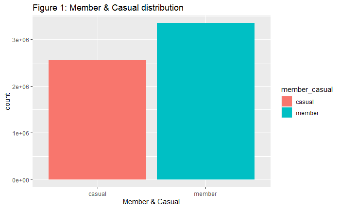

```r
fig(16,8)
ggplot(df_no_dups, aes(member_casual, fill = member_casual)) +
  geom_bar() +
  labs(x= "Member & Casual", title = "Figure 1: Member & Casual distribution")
```

By Year and Month

```r
df_no_dups %>%
  group_by(year_month) %>%
  summarise(freq = length(ride_id),
            percent_total = length(ride_id)/ nrow(df_no_dups) *100,
            'member_%' = sum(member_casual == "member")/ length(ride_id) *100,
            'casual_%' = sum(member_casual == "casual")/ length(ride_id) *100,
            'member_casual_diff' = (sum(member_casual == "member") - sum(member_casual == "casual"))/ length(ride_id) *100)
```

| year_month | freq | percent_total | member_% | casual_% | member_casual_diff |
| --- | --- | --- | --- | --- | --- |
| 2021 - 06 ( Jun ) | 1393 | 0.02360863 | 57.28643 | 42.71357 | 14.572864 |
| 2021 - 07 ( Jul ) | 824227 | 13.96903761 | 46.17284 | 53.82716 | -7.654323 |
| 2021 - 08 ( Aug ) | 802503 | 13.60085825 | 48.78636 | 51.21364 | -2.427281 |
| 2021 - 09 ( Sep ) | 756238 | 12.81675687 | 51.87335 | 48.12665 | 3.746704 |
| 2021 - 10 ( Oct ) | 630747 | 10.68992956 | 59.26084 | 40.73916 | 18.521689 |
| 2021 - 11 ( Nov ) | 360513 | 6.10999113 | 70.34559 | 29.65441 | 40.691182 |
| 2021 - 12 ( Dec ) | 247111 | 4.18804875 | 71.65403 | 28.34597 | 43.308068 |
| 2022 - 01 ( Jan ) | 103464 | 1.75351269 | 82.59105 | 17.40895 | 65.182092 |
| 2022 - 02 ( Feb ) | 115986 | 1.96573613 | 81.45724 | 18.54276 | 62.914490 |
| 2022 - 03 ( Mar ) | 283417 | 4.80336453 | 68.30254 | 31.69746 | 36.605073 |

[output cut: 3 more lines]

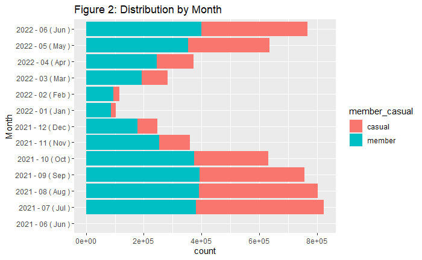

```r
df_no_dups %>%
  ggplot(aes(year_month, fill = member_casual)) +
  geom_bar() +
  labs(x="Month", title = "Figure 2: Distribution by Month") +
  coord_flip()
```

By Weekday

```r
df_no_dups %>%
  group_by(weekday) %>%
  summarise(freq = length(ride_id),
            percent_total = length(ride_id)/ nrow(df_no_dups) *100,
            'member_%' = sum(member_casual == "member")/ length(ride_id) *100,
            'casual_%' = sum(member_casual == "casual")/ length(ride_id) *100,
            'member_casual_diff' = (sum(member_casual == "member") - sum(member_casual == "casual"))/ length(ride_id) *100)
```

| weekday | freq | percent_total | member_% | casual_% | member_casual_diff |
| --- | --- | --- | --- | --- | --- |
| 1 - Mon | 772094 | 13.08549 | 61.23102 | 38.76898 | 22.462032 |
| 2 - Tue | 796199 | 13.49402 | 65.05283 | 34.94717 | 30.105665 |
| 3 - Wed | 802366 | 13.59854 | 64.22917 | 35.77083 | 28.458334 |
| 4 - Thu | 855572 | 14.50027 | 61.37181 | 38.62819 | 22.743615 |
| 5 - Fri | 852309 | 14.44497 | 55.05163 | 44.94837 | 10.103261 |
| 6 - Sat | 988579 | 16.75448 | 44.98507 | 55.01493 | -10.029851 |
| 7 - Sun | 833266 | 14.12223 | 47.65477 | 52.34523 | -4.690459 |

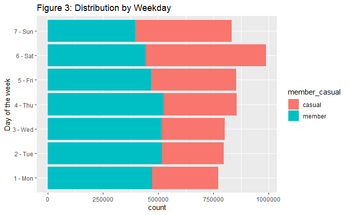

```r
df_no_dups %>%
  ggplot(aes(weekday, fill = member_casual)) +
  geom_bar() +
  labs(x="Day of the week", title = "Figure 3: Distribution by Weekday") +
  coord_flip()
```

By Hour of the day

```r
df_no_dups %>%
  group_by(start_hour) %>%
  summarise(freq = length(ride_id),
            percent_total = length(ride_id)/ nrow(df_no_dups) *100,
            'member_%' = sum(member_casual == "member")/ length(ride_id) *100,
            'casual_%' = sum(member_casual == "casual")/ length(ride_id) *100,
            'member_casual_diff' = (sum(member_casual == "member") - sum(member_casual == "casual"))/ length(ride_id) *100)
```

| start_hour | freq | percent_total | member_% | casual_% | member_casual_diff |
| --- | --- | --- | --- | --- | --- |
| 00 | 232611 | 3.9423021 | 76.63180 | 23.36820 | 53.2636032 |
| 01 | 259915 | 4.4050515 | 72.73724 | 27.26276 | 45.4744820 |
| 02 | 224574 | 3.8060906 | 63.74335 | 36.25665 | 27.4867082 |
| 03 | 253004 | 4.2879236 | 57.04179 | 42.95821 | 14.0835718 |
| 04 | 312587 | 5.2977390 | 55.11905 | 44.88095 | 10.2381097 |
| 05 | 355835 | 6.0307082 | 54.28640 | 45.71360 | 8.5727936 |
| 06 | 360254 | 6.1056016 | 52.24592 | 47.75408 | 4.4918308 |
| 07 | 371462 | 6.2955553 | 51.83330 | 48.16670 | 3.6665931 |
| 08 | 420045 | 7.1189422 | 54.22752 | 45.77248 | 8.4550465 |
| 09 | 499525 | 8.4659730 | 58.10960 | 41.89040 | 16.2192082 |

[output cut: 14 more lines]

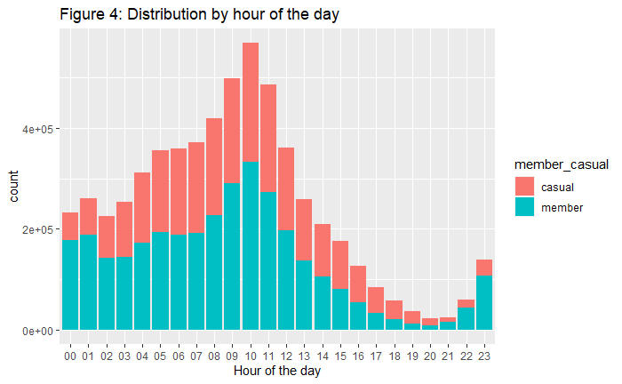

```r
df_no_dups %>%
  ggplot(aes(start_hour, fill = member_casual)) +
  geom_bar() +
  labs(x="Hour of the day", title = "Figure 4: Distribution by hour of the day")
```

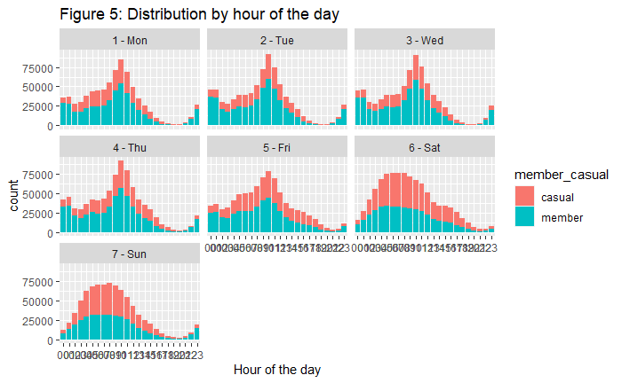

```r
df_no_dups %>%
  ggplot(aes(start_hour, fill = member_casual)) +
  geom_bar() +
  labs(x="Hour of the day", title = "Figure 5: Distribution by hour of the day") +
  facet_wrap(~weekday)
```

There’s a difference of riders types between weekend and mid_week

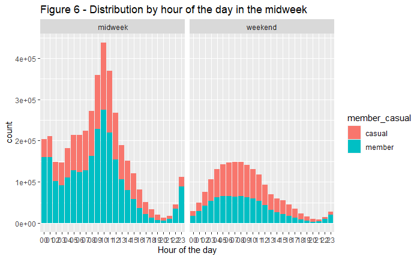

```r
df_no_dups %>%
    mutate(type_of_weekday = ifelse(weekday == '6 - Sat' | weekday == '7 - Sun',
                                   'weekend',
                                   'midweek')) %>%
    ggplot(aes(start_hour, fill=member_casual)) +
    labs(x="Hour of the day", title="Figure 6 - Distribution by hour of the day in the midweek") +
    geom_bar() +
    facet_wrap(~ type_of_weekday)
```

The two plots differs in some key ways:

- While the weekends have a rather smooth curve, the midweek have a more steep change in the number of riders.
- For midweek, there’s big increase during the mid-day then it falls towards the night. While that, For the weekend, the number of riders flow smoothly throughout the day, it starts off low then increase gradually towards 6-9am then starting falling.

It is important to question which type of bike used by which type of riders use during the day. From there, we can somewhat find out for what reasons they might use the bike for.

###### Ridedable type

```r
df_no_dups %>%
  group_by(rideable_type) %>%
  summarise(freq = length(ride_id),
            percent_total = length(ride_id)/ nrow(df_no_dups) *100,
            'member_%' = sum(member_casual == "member")/ length(ride_id) *100,
            'casual_%' = sum(member_casual == "casual")/ length(ride_id) *100,
            'member_casual_diff' = (sum(member_casual == "member") - sum(member_casual == "casual"))/ length(ride_id) *100)
```

| rideable_type | freq | percent_total | member_% | casual_% | member_casual_diff |
| --- | --- | --- | --- | --- | --- |
| classic_bike | 3189377 | 54.053710 | 61.80176 | 38.19824 | 23.60351 |
| docked_bike | 253371 | 4.294144 | 0.00000 | 100.00000 | -100.00000 |
| electric_bike | 2457637 | 41.652146 | 55.78802 | 44.21198 | 11.57604 |

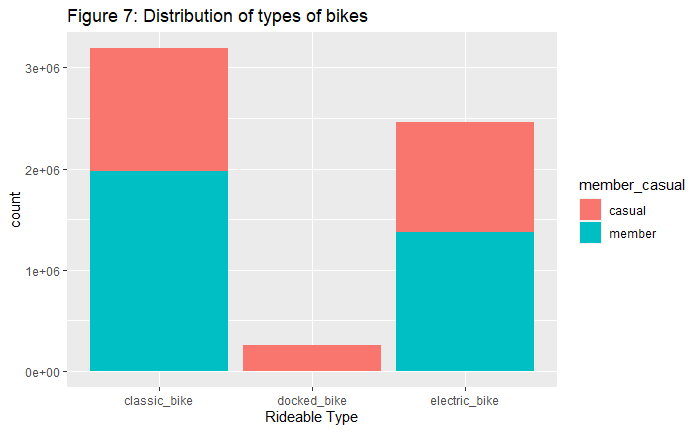

```r
ggplot(df_no_dups, aes(rideable_type, fill = member_casual)) +
  labs(x="Rideable Type", title = "Figure 7: Distribution of types of bikes") +
  geom_bar()
```

###### Other variables

Ride_time_m

```r
summary(df_no_dups$ride_time_minutes)
```

```
    Min.  1st Qu.   Median     Mean  3rd Qu.     Max.
 -137.42     6.28    11.17    20.28    20.20 49107.15
```

The max and min may give some problem when plotting some charts, since the min of ride time gives a negative value.

```r
quantiles <- quantile(df_no_dups$ride_time_minutes, seq(0,1, by=0.05))
quantiles
```

```
          0%           5%          10%          15%          20%          25%          30%          35%
 -137.416667     2.583333     3.716667     4.600000     5.433333     6.283333     7.133333     8.033333
         40%          45%          50%          55%          60%          65%          70%          75%
    8.983333    10.033333    11.166667    12.450000    13.900000    15.616667    17.666667    20.200000
         80%          85%          90%          95%         100%
   23.483333    27.916667    34.833333    50.166667 49107.150000
```

```r
df_no_outliers <- df_no_dups %>%
  filter(ride_time_minutes > as.numeric(quantiles["5%"])) %>%
  filter(ride_time_minutes > as.numeric(quantiles["95%"]))

print(paste("Removed", nrow(df_no_dups) - nrow(df_no_outliers), "rows as outliers"))
```

```
[1] "Removed 5605456 rows as outliers"
```

```r
df_no_outliers %>%
  group_by(member_casual) %>%
  summarise(mean = mean(ride_time_minutes),
            "first_quarter" = as.numeric(quantile(ride_time_minutes, 0.25)),
            "median" = median(ride_time_minutes),
            "third_quarter" = as.numeric(quantile(ride_time_minutes, 0.75)),
            "IR" = third_quarter - first_quarter)
```

| member_casual | mean | first_quarter | median | third_quarter | IR |
| --- | --- | --- | --- | --- | --- |
| casual | 152.3030 | 60.15000 | 75.86667 | 107.71667 | 47.56667 |
| member | 123.7741 | 55.48333 | 65.40000 | 92.76667 | 37.28333 |

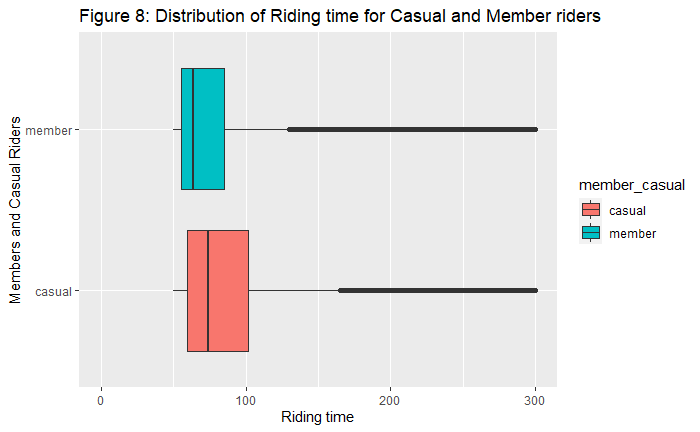

```r
df_no_outliers %>%
  ggplot(aes(x=member_casual, y= ride_time_minutes, fill = member_casual)) +
  labs(x="Members and Casual Riders", y="Riding time", title = "Figure 8: Distribution of Riding time for Casual and Member riders") +
  geom_boxplot() +
  coord_flip() +
  scale_y_continuous(limits = c(0,300))
```

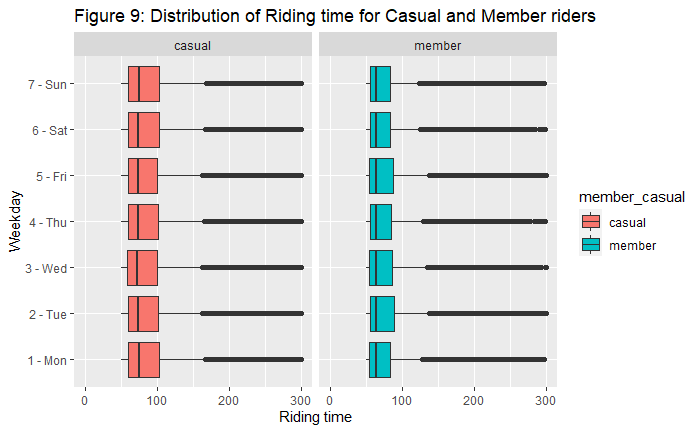

```r
  ggplot(df_no_outliers, aes(x=weekday, y= ride_time_minutes, fill = member_casual)) +
  labs(x="Weekday", y="Riding time", title = "Figure 9: Distribution of Riding time for Casual and Member riders") +
  geom_boxplot() +
  facet_wrap(~ member_casual)+
  coord_flip() +
  scale_y_continuous(limits = c(0,300))
```

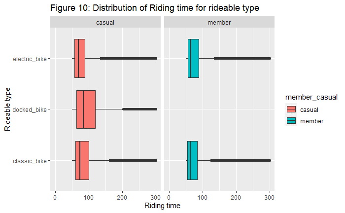

```r
ggplot(df_no_outliers, aes(x=rideable_type, y=ride_time_minutes, fill=member_casual)) +
    geom_boxplot() +
    facet_wrap(~ member_casual) +
    labs(x="Rideable type", y="Riding time", title="Figure 10: Distribution of Riding time for rideable type") +
    coord_flip() +
    scale_y_continuous(limits = c(0,300))
```

## Share

The share phase is usually done by building a presentation. But since this is only a showcase case study, this notebook can be seen as a presentation.

##### Guiding questions

- Were you able to answer the question of how annual members and casual riders use Cyclistic bike differently?
  - Yes. The data shows several differences between casual and member riders
- What story does your data tell?
  - The main story the data tells is that members follows a set schedule as seen on Figure 6. Members also have less riding time because they have a set route to take. Furthermore, members do not use docked bike to travel.
- How do your finding relate to your original question?
  - The findings build a profile for members, relating to “Finding the key differences between casual and annual riders”, also knowing why they use the bikes helps to find “How digital media could influence them”.
- Who is your audience? What is the best way to communicate with them?
  - The main target audience is the marketing analytics team. The best way to communicate is through a slide presentation of the findings.
- Can data visualization help you share your finding?
  - Yes, the important part of the findings is through data visualization.
- Is your presentation accessible to you audience?
  - Yes, the charts were made using vibrant colors and correct labels.

## Act

The act phase would be done by the marketing team of the company. The main takeaway will be the top three recommendations for the marketing.

##### Guiding questions

- What is your final conclusion based on your analysis?
  - Members and casual riders have different routine activities when using the bikes. The conclusion is further stated in the share phase.
- How could your team and business apply your insights?
  - The insights could be implemented when preparing a marketing campaign for converting casual to members. The marketing team can have a focus on workers as a green way to get to work.
- What next steps would you or your stakeholders take based on your findings?
  - Further analysis is needed to improve findings. However, the marketing team can take the key information from this analysis to build a marketing campaign.
- Is there additional data you could use to expand on your findings?
  - Climate data
  - More information about members